# GITR Analysis in Kidney renal clear cell carcinoma

Arjun Mittal

July 8, 2022

# Examining GITR High Expression in Low PDL1 Expressing Tumors

```r
#removed tpm, fpkm, and stranded value
df.raw.counts <- as.data.frame(raw.counts)
df.raw.counts <- df.raw.counts %>% dplyr::select(-contains('tpm'))
df.raw.counts <- df.raw.counts %>% dplyr::select(-contains('fpkm'))
df.raw.counts <- df.raw.counts %>% dplyr::select(-contains('second'))
df.raw.counts <- df.raw.counts %>% dplyr::select(-contains('first'))
genes <- df.raw.counts[1:3]
ids <- df.raw.counts$gene_id
ids <- gsub('(ENSG[0-9]+)\\.[0-9]+', '\\1', ids)
rownames(df.raw.counts) <- ids
#rownames(df.raw.counts) <- df.raw.counts$gene_id
df.raw.counts <- df.raw.counts %>% subset(select=-c(1,2,3))
colnames(df.raw.counts) <- gsub('unstranded_', '', colnames(df.raw.counts))
colnames(df.raw.counts) <- substring(colnames(df.raw.counts), 1, 16)
df.raw.counts <- df.raw.counts %>% dplyr::select(unique(colnames(df.raw.counts)))
df.raw.counts <- df.raw.counts %>% dplyr::select(-contains('-11A'))
df.raw.counts <- df.raw.counts %>% dplyr::select(-contains('-11B'))
df.raw.counts <- df.raw.counts %>% dplyr::select(-contains('5633-01B'),
                                                 -contains('A4W0-05A'),
                                                 -contains('3923-01B'),
                                                 -contains('3924-01B'),
                                                 -contains('5635-01B')
                                                 )
#convert df to edgeR list
dge.counts <- DGEList(as.matrix(df.raw.counts))
```

```r
sumCounts <- dge.counts$counts
sums <- colSums(dge.counts$counts)
sums <- as.data.frame(sums)
sums$sample <- rownames(sums)
names(sums) <- c('Total_Counts', 'Sample')
cat('## Total Counts per Sample')
```

## Total Counts per Sample

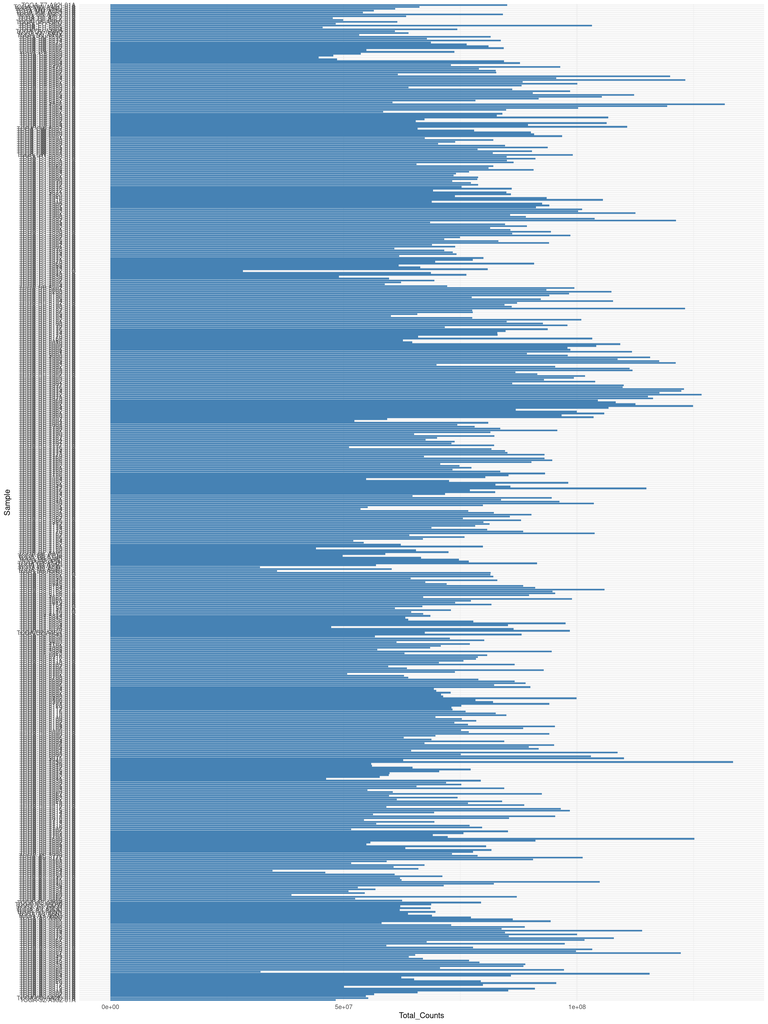

```r
d <- ggplot(sums, aes(x=Total_Counts, y=Sample)) +
    geom_bar(stat='identity', fill='steelblue') +
    theme_minimal()
d
```

```r
#library(biomaRt)
#ensembl = useMart("ensembl",dataset="hsapiens_gene_ensembl")
geneids <- rownames(dge.counts)


#remove duplicated genes
genes <- genes[!duplicated(genes$gene_id),]
dge.counts$genes <- genes


#look into fixing this too by removing decimal points
```

```r
#Note PDL1 = CD274, GITR=TNFRSF18, TIM3=HAVCR2, couldn't find KIR3DL1
interest_list <- dge.counts[dge.counts$genes$gene_name %in% c('FOXP3', 'TNFRSF18','IDO1', 'LAG3', 'CSF1R', 'HAVCR2', 'CTLA4', 'CD274'),]
```

## Determining Expression of 8 Genes of Interest Across the Samples

The genes of interest in our study were: CTLA4, FOXP3, GITR (TNFRSF18), IDO1, LAG3, CSF1R, TIM3 (HAVCR2), and PDL1 (CD274).

```r
foxp3 <- interest_list[interest_list$genes$gene_name == 'FOXP3',]
foxp3 <- as.data.frame(t(foxp3$counts))
colnames(foxp3) <- "counts"
foxp3$gene <- "FOXP3"
foxp3 <- foxp3 %>% mutate(quartile_foxp3 = ntile(counts, 4))
dge.counts$foxp3 <- foxp3

gitr <- interest_list[interest_list$genes$gene_name == 'TNFRSF18',]
gitr <- as.data.frame(t(gitr$counts))
colnames(gitr) <- "counts"
gitr$gene <- "GITR"
gitr <- gitr %>% mutate(quartile_gitr = ntile(counts, 4))
dge.counts$gitr <- gitr

ido1 <- interest_list[interest_list$genes$gene_name == 'IDO1',]
ido1 <- as.data.frame(t(ido1$counts))
colnames(ido1) <- "counts"
ido1$gene <- "IDO1"
ido1 <- ido1 %>% mutate(quartile_ido1 = ntile(counts, 4))
dge.counts$ido1 <- ido1

lag3 <- interest_list[interest_list$genes$gene_name == 'LAG3',]
lag3 <- as.data.frame(t(lag3$counts))
colnames(lag3) <- "counts"
lag3$gene <- "LAG3"
lag3 <- lag3 %>% mutate(quartile_lag3 = ntile(counts, 4))
dge.counts$lag3 <- lag3

csf1r <- interest_list[interest_list$genes$gene_name == 'CSF1R',]
csf1r <- as.data.frame(t(csf1r$counts))
colnames(csf1r) <- "counts"
csf1r$gene <- "CSF1R"
csf1r <- csf1r %>% mutate(quartile_csf1r = ntile(counts, 4))
dge.counts$csf1r <- csf1r

tim3 <- interest_list[interest_list$genes$gene_name == 'HAVCR2',]
tim3 <- as.data.frame(t(tim3$counts))
colnames(tim3) <- "counts"
tim3$gene <- "HAVCR2"
tim3 <- tim3 %>% mutate(quartile_tim3 = ntile(counts, 4))
dge.counts$tim3 <- tim3


ctla4 <- interest_list[interest_list$genes$gene_name == 'CTLA4',]
ctla4 <- as.data.frame(t(ctla4$counts))
colnames(ctla4) <- "counts"
ctla4$gene <- "CTLA4"
ctla4 <- ctla4 %>% mutate(quartile_ctla4 = ntile(counts, 4))
dge.counts$ctla4 <- ctla4

pdl1 <- interest_list[interest_list$genes$gene_name == 'CD274',]
pdl1 <- as.data.frame(t(pdl1$counts))
colnames(pdl1) <- "counts"
pdl1$gene <- "CD274"
pdl1 <- pdl1 %>% mutate(quartile_pdl1 = ntile(counts, 4))
dge.counts$pdl1 <- pdl1
```

```r
test2 <- foxp3
test2$sample_names <- row.names(test2)
test2 <- test2 %>% subset(select=c(-gene,-counts))

test3 <- gitr
test3$sample_names <- row.names(test3)
test3 <- test3 %>% subset(select=c(-gene,-counts))

test4 <- ido1
test4$sample_names <- row.names(test4)
test4 <- test4 %>% subset(select=c(-gene,-counts))

test5 <- lag3
test5$sample_names <- row.names(test5)
test5 <- test5 %>% subset(select=c(-gene,-counts))

test6 <- csf1r
test6$sample_names <- row.names(test6)
test6 <- test6 %>% subset(select=c(-gene,-counts))

test7 <- tim3
test7$sample_names <- row.names(test7)
test7 <- test7 %>% subset(select=c(-gene,-counts))

test8 <- ctla4
test8$sample_names <- row.names(test8)
test8 <- test8 %>% subset(select=c(-gene,-counts))

test9 <- pdl1
test9$sample_names <- row.names(test9)
test9 <- test9 %>% subset(select=c(-gene,-counts))

list_of_all_gene_quartiles <- list(test2, test3, test4, test5, test6, test7, test8, test9)

quartiles_of_genes <- list_of_all_gene_quartiles %>% purrr::reduce(full_join, by='sample_names')
quartiles_of_genes <- quartiles_of_genes %>% dplyr::select(sample_names, everything())
```

```r
#heatmap of quartiles
library(reshape)
library(ggplot2)
library(ComplexHeatmap)
heatmap_frame <- quartiles_of_genes
rownames(heatmap_frame) <- heatmap_frame$sample_names
heatmap_frame <- heatmap_frame %>% subset(select=-sample_names)
heatmap_frame <- heatmap_frame[order(heatmap_frame$quartile_pdl1),]

cat('\n\n\n')
```

```r
cat('### Quartile Expression of Genes of Interest Across Samples')
```

### Quartile Expression of Genes of Interest Across Samples

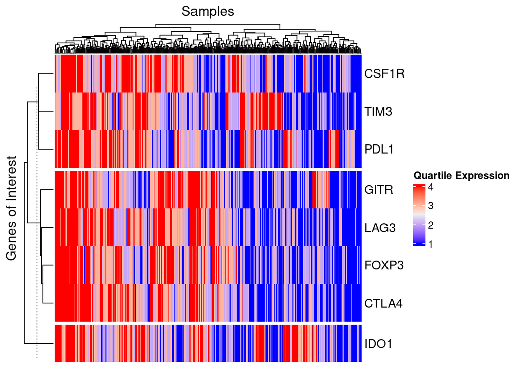

```r
test_frame <- heatmap_frame
colnames(test_frame) <- c('FOXP3', 'GITR', 'IDO1', 'LAG3', 'CSF1R', 'TIM3', 'CTLA4', 'PDL1')

test_frame <- as.matrix(t(test_frame))
set.seed(3)
Heatmap(test_frame, name='Quartile Expression', column_title='Samples',
        row_title='Genes of Interest', clustering_distance_rows='euclidean',
        clustering_distance_columns='euclidean', show_column_names=FALSE, k=3)
```

```r
#clustering work
exprs <- as.matrix(t(heatmap_frame))
eucl_dist <- dist(matrix(exprs), method = 'euclidean')
hie_clust = hclust(eucl_dist, method = 'complete')
cat('\n\n\n')
```

```r
cat('### Unsupervised Euclidean Clustering of Quartile Expression Across Samples\n')
```

### Unsupervised Euclidean Clustering of Quartile Expression Across Samples

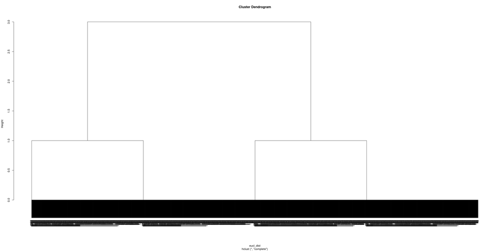

```r
plot(hie_clust)
```

```r
master <- quartiles_of_genes #all samples, N=368
master <- master %>% subset(select=c(-quartile_foxp3, -quartile_ctla4, -quartile_ido1,-quartile_lag3,-quartile_csf1r,-quartile_tim3))

group1 <- master %>% filter(quartile_gitr >=3 & quartile_pdl1 >=3) #group1, N=
group1 <- group1 %>% subset(select=c(sample_names))

group2 <- master %>% filter(quartile_gitr >=3 & quartile_pdl1 <=2) #group2, N=
group2 <- group2 %>% subset(select=c(sample_names))

group3 <- master %>% filter(quartile_gitr <=2 & quartile_pdl1 <= 2) #group3, N=
group3 <- group3 %>% subset(select=c(sample_names))

group4 <- master %>% filter(quartile_pdl1 >=3 & quartile_gitr <=2) #group 4, N=


#relevel groups to account for our 4 conditions
levels(dge.counts$samples$group) <- c(levels(dge.counts$samples$group), 2,3,4)

dge.counts$samples$sample_name <- rownames(dge.counts$samples)

#match with what group it should go in and then adjust group value accordingly
for (x in 1:nrow(dge.counts$samples)){
    if (dge.counts$samples[x,4] %in% group1$sample_names){
       dge.counts$samples[x,1] <- 1
    }
    else if (dge.counts$samples[x,4] %in% group2$sample_names){
       dge.counts$samples[x,1] <- 2
    }
    else if (dge.counts$samples[x,4] %in% group3$sample_names){
       dge.counts$samples[x,1] <- 3
    }
    else{
       dge.counts$samples[x,1] <- 4
    }
}

#remove sample name column I added for convenience
dge.counts$samples <- dge.counts$samples %>% subset(select=-sample_name)
#dge.counts$samples <- dge.counts$samples %>% dplyr::filter(group != 4) #don't care for this
```

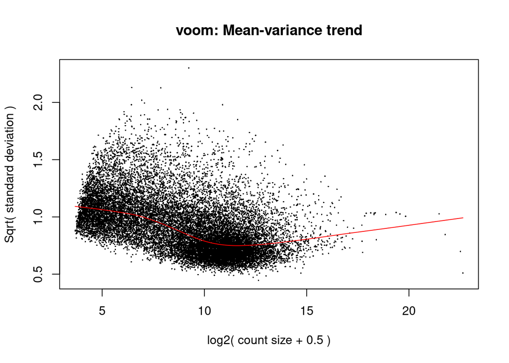

```r
group <- dge.counts$sample$group
#hmm
design <- model.matrix(~0+group)
colnames(design) <- c("Group1","Group2","Group3", 'Group4')

contr.matrix <- makeContrasts(
                              Group2vsGroup1 = Group2 - Group1,
                              Group2vsGroup3 = Group2 - Group3,
                              Group1vsGroup3 = Group1 - Group3,
                              levels = colnames(design))

v <- voom(dge.counts, design, plot = TRUE)
```

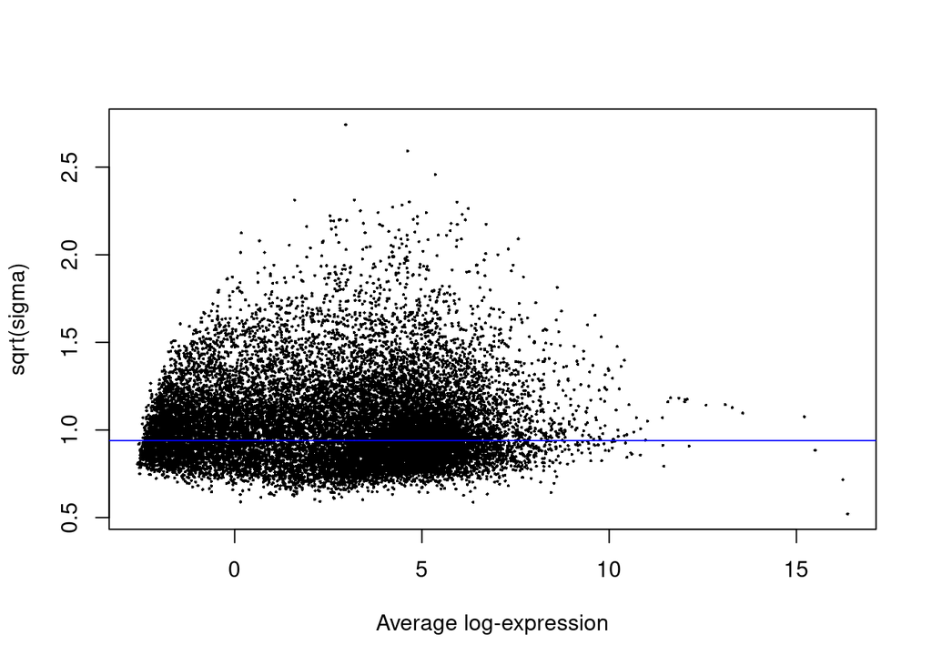

```r
vfit <- lmFit(v, design)
vfit <- contrasts.fit(vfit, contrasts=contr.matrix)
efit <- eBayes(vfit)

plotSA(efit)
```

```r
summary(decideTests(efit))
```

```
##        Group2vsGroup1 Group2vsGroup3 Group1vsGroup3
## Down             3962           5157           4483
## NotSig          11179           8265           9977
## Up               3370           5089           4051
```

```r
tfit <- treat(vfit, lfc=0.5)
dt <- decideTests(tfit)
summary(dt)
```

```
##        Group2vsGroup1 Group2vsGroup3 Group1vsGroup3
## Down                7             25              7
## NotSig          18500          18198          17766
## Up                  4            288            738
```

```r
write.fit(tfit,dt,file='results_gitr_renal_clear_cell.txt')
```

# Examining Differential Expression Across Contrasts

From the quartile analysis, three main groups of interest were determined. Group 1 is samples with high PD-L1 expression (T-cell inflammed) and high GITR expression Group 2 is samples with low PD-L1 expression (T-cell cold) and high GITR expression Group 3 is samples with low PD-L1 expression (T-cell cold) and low GITR expression

Group 1 intuitively makes sense as samples with T cell infiltration, high GITR expression is expected given normal T cell function and the immune-suppressing signals upregulated in tumor microenvironment. Thus this serves a positive control to an extent.

Group 2 is the group most similar to an experimental group as the high GITR expression in a T-cell cold environment is aberrant and it is of interest to see if other genes correlate with this phenotype to explain some sort of immune-excluding mechanism

Group 3 also makes intuitive sense as samples with low PD-L1 should also have low GITR since there are no T cells there to express the protein

The contrasts ultimately examined were - Group 2 vs Group 1 - Group 2 vs Group 3 - Group 1 vs Group 3

## Differential Expression Across the Three Contrasts

```r
top_group2_vs_group1 <- topTreat(tfit, coef=1, n=Inf)
top_group2_vs_group3 <- topTreat(tfit, coef=2, n=Inf)
top_group1_vs_group3 <- topTreat(tfit, coef=3, n=Inf)

cat('\n\n### High GITR & Low PDL1 Group vs High GITR & High PDL1 Group')
```

### High GITR & Low PDL1 Group vs High GITR & High PDL1 Group

```r
knitr::kable(head(top_group2_vs_group1[order(top_group2_vs_group1$adj.P.Val),],n=10))
```

|  | gene_id | gene_name | gene_type | logFC | AveExpr | t | P.Value | adj.P.Val |
| --- | --- | --- | --- | --- | --- | --- | --- | --- |
| ENSG00000120217 | ENSG00000120217.14 | CD274 | protein_coding | -1.3277827 | 2.1474344 | -8.987663 | 0.00e+00 | 0.0000000 |
| ENSG00000229754 | ENSG00000229754.1 | CXCR2P1 | transcribed_unprocessed_pseudogene | -1.8571526 | 0.2753562 | -5.818304 | 0.00e+00 | 0.0000476 |
| ENSG00000169245 | ENSG00000169245.6 | CXCL10 | protein_coding | -1.4363308 | 4.0046337 | -5.359627 | 1.00e-07 | 0.0003840 |
| ENSG00000154451 | ENSG00000154451.14 | GBP5 | protein_coding | -1.2995013 | 3.7746165 | -5.244471 | 1.00e-07 | 0.0005243 |
| ENSG00000169248 | ENSG00000169248.13 | CXCL11 | protein_coding | -1.4045389 | 1.8015773 | -4.944995 | 5.00e-07 | 0.0018930 |
| ENSG00000178150 | ENSG00000178150.10 | ZNF114 | protein_coding | 1.6867065 | -0.8214347 | 4.723035 | 1.50e-06 | 0.0045921 |
| ENSG00000163606 | ENSG00000163606.11 | CD200R1 | protein_coding | -1.1923525 | 0.9594706 | -4.649694 | 2.10e-06 | 0.0055517 |
| ENSG00000138755 | ENSG00000138755.6 | CXCL9 | protein_coding | -1.3240161 | 5.0456815 | -4.585373 | 2.80e-06 | 0.0065434 |
| ENSG00000105427 | ENSG00000105427.10 | CNFN | protein_coding | 1.2896560 | -1.3365110 | 4.341698 | 8.50e-06 | 0.0174127 |
| ENSG00000143590 | ENSG00000143590.14 | EFNA3 | protein_coding | 0.9992884 | 1.0401154 | 4.301014 | 1.01e-05 | 0.0175148 |

```r
cat('\n\n### High GITR & Low PDL1 Group vs Low GITR & Low PDL1 Group')
```

### High GITR & Low PDL1 Group vs Low GITR & Low PDL1 Group

```r
knitr::kable(head(top_group2_vs_group3[order(top_group2_vs_group3$adj.P.Val),],n=10))
```

|  | gene_id | gene_name | gene_type | logFC | AveExpr | t | P.Value | adj.P.Val |
| --- | --- | --- | --- | --- | --- | --- | --- | --- |
| ENSG00000186891 | ENSG00000186891.14 | TNFRSF18 | protein_coding | 1.954915 | -0.3748074 | 12.826617 | 0 | 0.0e+00 |
| ENSG00000225783 | ENSG00000225783.8 | MIAT | lncRNA | 1.941467 | 0.9987997 | 6.966471 | 0 | 0.0e+00 |
| ENSG00000267369 | ENSG00000267369.1 | TAF5LP1 | processed_pseudogene | 1.406730 | -0.4818510 | 6.639667 | 0 | 2.0e-07 |
| ENSG00000159753 | ENSG00000159753.14 | CARMIL2 | protein_coding | 1.416378 | 0.8385058 | 6.388726 | 0 | 8.0e-07 |
| ENSG00000105639 | ENSG00000105639.20 | JAK3 | protein_coding | 1.223927 | 4.2554372 | 6.266073 | 0 | 1.4e-06 |
| ENSG00000124256 | ENSG00000124256.15 | ZBP1 | protein_coding | 1.361577 | 0.3590002 | 6.172453 | 0 | 2.1e-06 |
| ENSG00000188282 | ENSG00000188282.12 | RUFY4 | protein_coding | 1.771453 | -1.5185925 | 6.134478 | 0 | 2.2e-06 |
| ENSG00000049768 | ENSG00000049768.16 | FOXP3 | protein_coding | 1.438455 | 0.3647951 | 5.999043 | 0 | 4.2e-06 |
| ENSG00000211772 | ENSG00000211772.11 | TRBC2 | TR_C_gene | 1.443795 | 3.7002752 | 5.870922 | 0 | 7.8e-06 |
| ENSG00000027869 | ENSG00000027869.12 | SH2D2A | protein_coding | 1.323501 | 1.6737002 | 5.853577 | 0 | 7.8e-06 |

```r
cat('\n\n### High GITR & High PDL1 Group vs Low GITR & Low PDL1 Group')
```

### High GITR & High PDL1 Group vs Low GITR & Low PDL1 Group

```r
knitr::kable(head(top_group1_vs_group3[order(top_group1_vs_group3$adj.P.Val),],n=10))
```

|  | gene_id | gene_name | gene_type | logFC | AveExpr | t | P.Value | adj.P.Val |
| --- | --- | --- | --- | --- | --- | --- | --- | --- |
| ENSG00000154451 | ENSG00000154451.14 | GBP5 | protein_coding | 2.406016 | 3.7746165 | 11.28199 | 0 | 0 |
| ENSG00000238121 | ENSG00000238121.6 | LINC00426 | lncRNA | 1.998146 | -0.3339703 | 11.12379 | 0 | 0 |
| ENSG00000160185 | ENSG00000160185.15 | UBASH3A | protein_coding | 2.000449 | 0.7337720 | 10.89587 | 0 | 0 |
| ENSG00000181847 | ENSG00000181847.12 | TIGIT | protein_coding | 2.231867 | 1.7011511 | 10.78974 | 0 | 0 |
| ENSG00000226979 | ENSG00000226979.9 | LTA | protein_coding | 2.001542 | -1.0246541 | 10.77537 | 0 | 0 |
| ENSG00000186891 | ENSG00000186891.14 | TNFRSF18 | protein_coding | 1.702684 | -0.3748074 | 10.70351 | 0 | 0 |
| ENSG00000177494 | ENSG00000177494.6 | ZBED2 | protein_coding | 2.916143 | -1.3621027 | 10.69355 | 0 | 0 |
| ENSG00000124256 | ENSG00000124256.15 | ZBP1 | protein_coding | 1.912576 | 0.3590002 | 10.69072 | 0 | 0 |
| ENSG00000163599 | ENSG00000163599.17 | CTLA4 | protein_coding | 2.311810 | -0.3583103 | 10.58382 | 0 | 0 |
| ENSG00000147138 | ENSG00000147138.3 | GPR174 | protein_coding | 2.146435 | 1.4155521 | 10.49140 | 0 | 0 |

```r
#head(top_group2_vs_group1)
#head(top_group2_vs_group3)
#head(top_group1_vs_group3)
```

## Mean Difference Plots Across the Three Contrasts

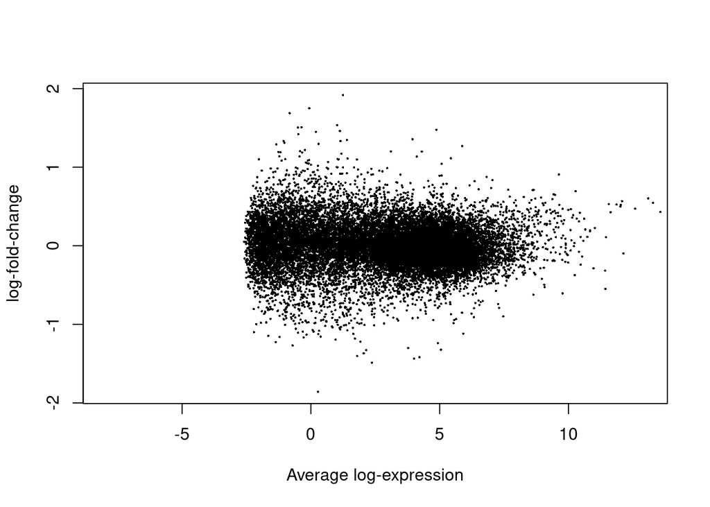

```r
library(gplots)
library(Glimma)
top_group2_vs_group1_genes <- top_group2_vs_group1$gene_id[1:100]
i <- which(v$genes$gene_id %in% top_group2_vs_group1_genes)
mycol <- colorpanel(1000, "blue", "red", 'yellow')

#pdf('heatmap_lcpm')
#heatmap.2(lcpm[i,], scale='row', labRow=v$genes$gene_name[i], labCol=group, col=mycol,
#          trace='none', density.info='none', lhei=c(2,10), dendrogram='column')
#dev.off()

#pdf('mean-difference-plot-unweighted_group_2_vs_group_1')
plotMD(tfit,column=1,main=colnames(tfit)[4], xlim=c(-8,13))
```

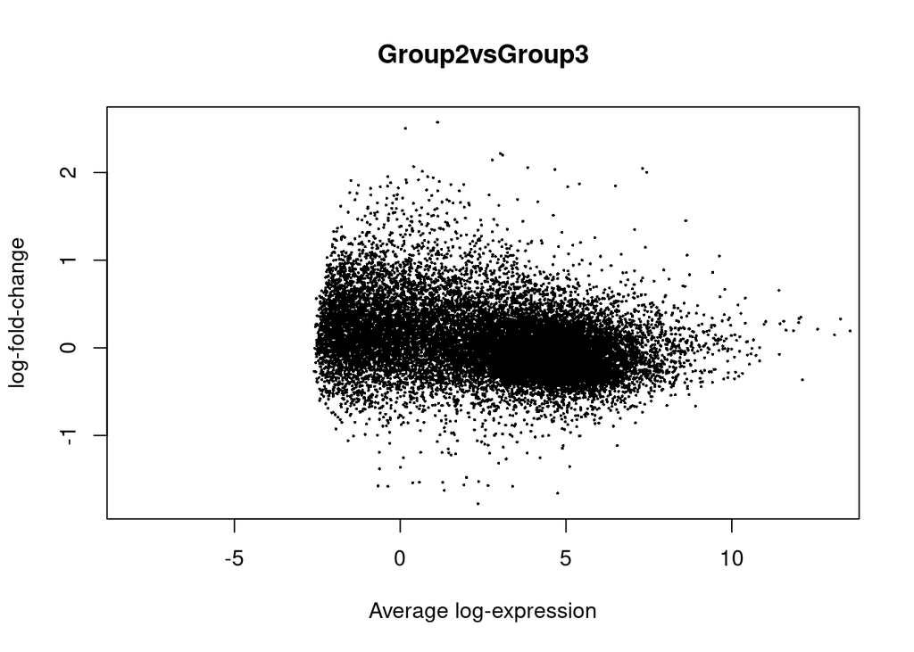

```r
#dev.off()

#pdf('mean-difference-plot-unweighted_group_2_vs_group_3')
plotMD(tfit,column=2,main=colnames(tfit)[2], xlim=c(-8,13))
```

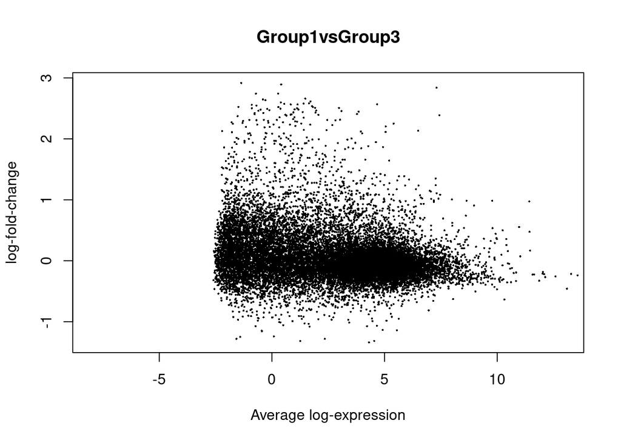

```r
#dev.off()

#pdf('mean-difference-plot-unweighted_group_1_vs_group_3')
plotMD(tfit,column=3,main=colnames(tfit)[3], xlim=c(-8,13))
```

```r
#dev.off()
glMDPlot(tfit, coef=1, status=dt, main=colnames(tfit)[1], launch=FALSE)
```

```r
tpm <- as.data.frame(raw.counts) %>% dplyr::select(-contains('first'))
tpm <- tpm %>% dplyr::select(-contains('second'))
tpm <- tpm %>% dplyr::select(-contains('fpkm'))
tpm <- tpm %>% dplyr::select(-starts_with('unstranded'))
tids <- tpm$gene_id
tids <- gsub('(ENSG[0-9]+)\\.[0-9]+', '\\1', tids)
tpm$gene_id <- tids
#rownames(tpm) <- tids
#tpm <- tpm %>% subset(select=-c(3))
#remove all empty values or NA listed for gene_name
tpm <- tpm[!(is.na(tpm$gene_name) | tpm$gene_name == ''), ]
```

```r
#Get duplicate gene names
dups <- unique(tpm$gene_name[duplicated(tpm$gene_name)])
repeats <- tpm[tpm$gene_name %in% dups,]
repeats <- repeats[order(repeats$gene_name),]

for (i in 1:length(dups)){
    my.df = NULL
    my.df = repeats[repeats$gene_name == dups[i],, drop=F]

    my.df = data.frame(Gene = my.df$gene_name, my.df, stringsAsFactors = F)
    row.names(my.df) = 1:nrow(my.df)
    my.df <- my.df %>% subset(select=c(-gene_id, -gene_name, -gene_type))

    my.df.0 = NULL
    my.df.0 = my.df

    my.df = data.frame(mean = apply(my.df[,-1], 1, mean, na.rm = T))

    my.df.row = 1
    if(my.df$mean[1] < my.df$mean[2]) { my.df.row = 2}

    if(i == 1){
        z = my.df.0[my.df.row,, drop=F]
    }
    else{
        z = rbind(z, my.df.0[my.df.row,, drop=F])
    }

}

row.names(z) = z$Gene
z=z[,-1]
z$gene_name <- rownames(z)
tpm <- tpm %>% subset(select=c(-gene_id,-gene_type))
rownames(z) <- NULL
rownames(tpm) <- NULL

z <- z %>% dplyr::select(gene_name, everything())
names(z) <- names(tpm)


no_repeat_tpm <- rbind(tpm[!tpm$gene_name %in% dups,, drop=F], z)
rownames(no_repeat_tpm) <- no_repeat_tpm$gene_name
no_repeat_tpm <- no_repeat_tpm %>% subset(select=c(-gene_name))

#dim(no_repeat_tpm)

colnames(no_repeat_tpm) <- gsub('tpm_unstranded_', '', colnames(no_repeat_tpm))
colnames(no_repeat_tpm) <- substring(colnames(no_repeat_tpm), 1, 16)
no_repeat_tpm <- no_repeat_tpm %>% dplyr::select(unique(colnames(no_repeat_tpm)))
no_repeat_tpm <- no_repeat_tpm %>% dplyr::select(-contains('-11A'))
no_repeat_tpm <- no_repeat_tpm %>% dplyr::select(-contains('-11B'))
df.raw.counts <- df.raw.counts %>% dplyr::select(-contains('5633-01B'),
                                                 -contains('A4W0-05A'),
                                                 -contains('3923-01B'),
                                                 -contains('3924-01B'),
                                                 -contains('5635-01B')
                                                 )
```

# Deconvolution of Samples

```r
colnames(res_quantiseq) <- gsub('tpm_', '', colnames(res_quantiseq))
tester <- dge.counts$samples
group1_samps <- tester[tester$group == 1,]
group2_samps <- tester[tester$group == 2,]
group3_samps <- tester[tester$group == 3,]
group4_samps <- tester[tester$group == 4,]

group1_cell <- res_quantiseq %>% dplyr::select(cell_type, rownames(group1_samps))
group2_cell <- res_quantiseq %>% dplyr::select(cell_type, rownames(group2_samps))
group3_cell <- res_quantiseq %>% dplyr::select(cell_type, rownames(group3_samps))
group4_cell <- res_quantiseq %>% dplyr::select(cell_type, rownames(group4_samps))
```

```r
cat("\n\n")
```

```r
cat("## Grouped Sample Comparision\n")
```

## Grouped Sample Comparision

```r
cat("### QuantiSeq Results")
```

### QuantiSeq Results

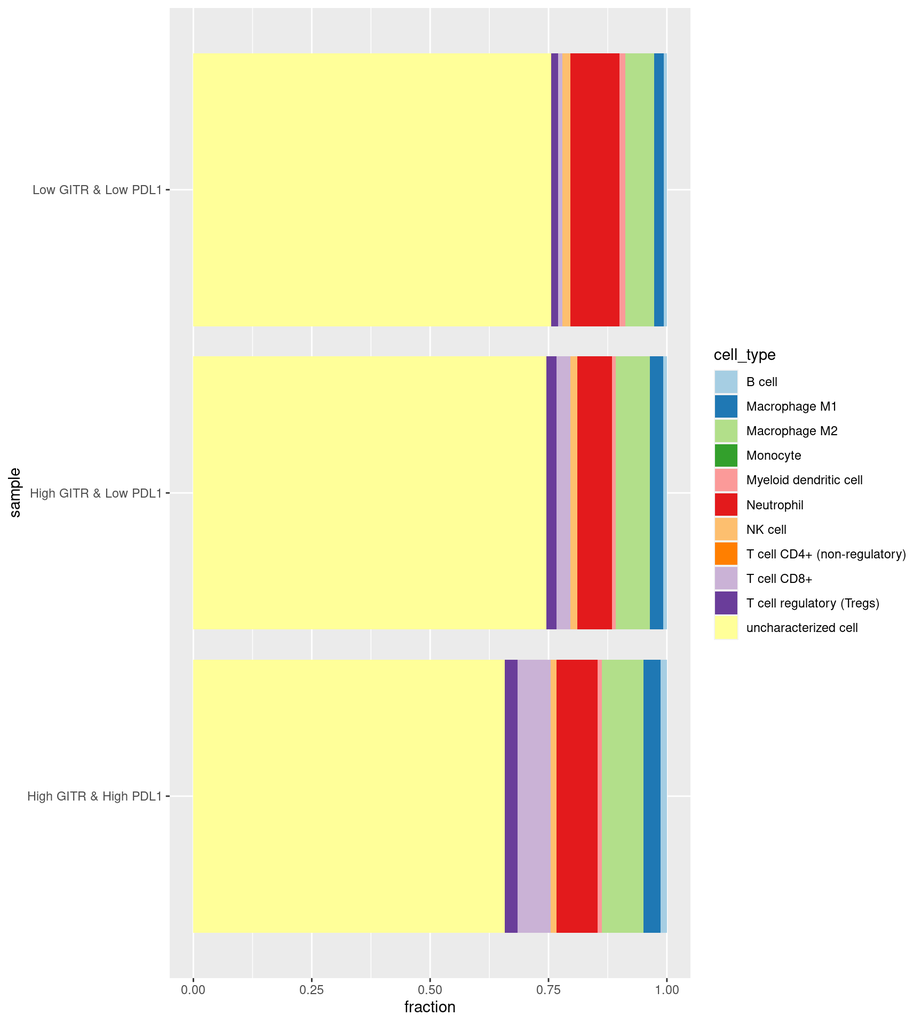

```r
names(group_res_quantiseq) <- c('cell_type', 'High GITR & High PDL1', 'High GITR & Low PDL1', 'Low GITR & Low PDL1', 'group4')
group_res_quantiseq <- group_res_quantiseq %>% dplyr::select(-group4)

group_res_quantiseq %>%
    gather(sample, fraction, -cell_type) %>%
    ggplot(aes(x=sample, y=fraction, fill=cell_type)) +
    geom_bar(stat = 'identity') +
    coord_flip() +
    scale_fill_brewer(palette = 'Paired') +
    scale_x_discrete(limits = rev(levels(group_res_quantiseq)))
```

```r
cat('\n\n\n\n')
```

```r
cat('### EPIC Results')
```

### EPIC Results

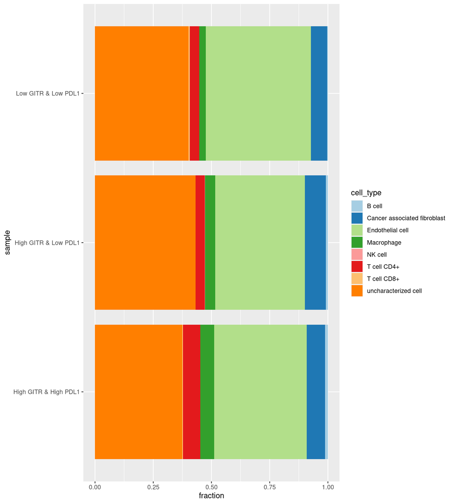

```r
names(group_res_epic) <- c('cell_type', 'High GITR & High PDL1', 'High GITR & Low PDL1', 'Low GITR & Low PDL1', 'group4')
group_res_epic <- group_res_epic %>% dplyr::select(-group4)

group_res_epic %>%
    gather(sample, fraction, -cell_type) %>%
    ggplot(aes(x=sample, y=fraction, fill=cell_type)) +
    geom_bar(stat = 'identity') +
    coord_flip() +
    scale_fill_brewer(palette = 'Paired') +
    scale_x_discrete(limits = rev(levels(group_res_epic)))
```

```r
cat('\n\n\n\n')
```

```r
cat('### CIBERSORT Results')
```

### CIBERSORT Results

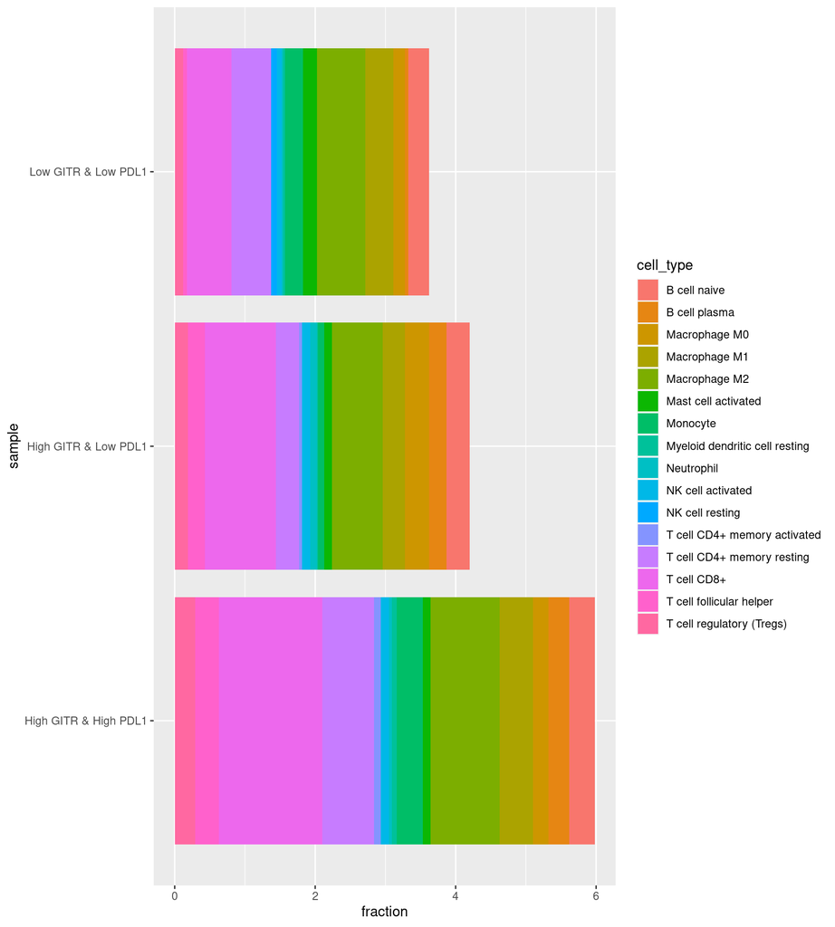

```r
names(group_res_cibersort) <- c('cell_type', 'High GITR & High PDL1', 'High GITR & Low PDL1', 'Low GITR & Low PDL1', 'group4')
group_res_cibersort <- group_res_cibersort %>% dplyr::select(-group4)
group_res_cibersort <- group_res_cibersort[rowSums(group_res_cibersort[,-1]) > 0,]
group_res_cibersort %>%
    gather(sample, fraction, -cell_type) %>%
    ggplot(aes(x=sample, y=fraction, fill=cell_type)) +
    geom_bar(stat = 'identity') +
    coord_flip() +
    #scale_fill_brewer(palette = 'Paired') +
    scale_x_discrete(limits = rev(levels(group_res_cibersort)))
```

```r
cat("\n\n\n\n")
```

```r
cat("### MCP Results")
```

### MCP Results

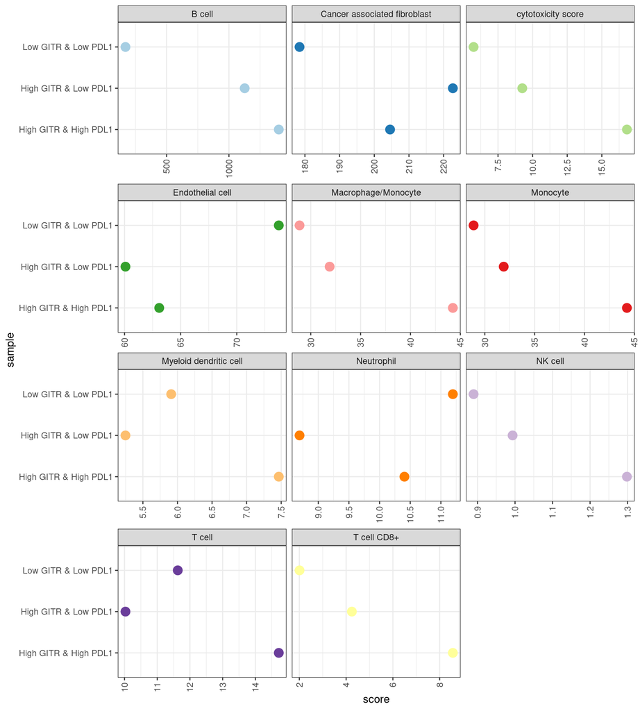

```r
names(group_res_mcp_counter) <- c('cell_type', 'High GITR & High PDL1', 'High GITR & Low PDL1', 'Low GITR & Low PDL1', 'group4')
group_res_mcp_counter <- group_res_mcp_counter %>% dplyr::select(-group4)

group_res_mcp_counter %>%
    gather(sample, score, -cell_type) %>%
  ggplot(aes(x=sample, y=score, color=cell_type)) +
    geom_point(size=4) +
    facet_wrap(~cell_type, scales="free_x", ncol=3) +
    scale_color_brewer(palette="Paired", guide=FALSE) +
    coord_flip() +
    theme_bw() +
    theme(axis.text.x = element_text(angle = 90, vjust = 0.5, hjust=1))
```

```r
cat('\n\n\n\n')
```

```r
cat('### TIMER Results')
```

### TIMER Results

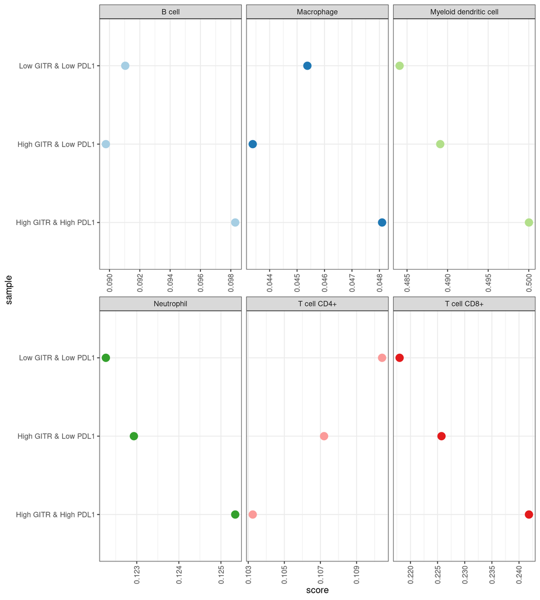

```r
names(group_res_timer) <- c('cell_type', 'High GITR & High PDL1', 'High GITR & Low PDL1', 'Low GITR & Low PDL1', 'group4')
group_res_timer <- group_res_timer %>% dplyr::select(-group4)

group_res_timer %>%
    gather(sample, score, -cell_type) %>%
  ggplot(aes(x=sample, y=score, color=cell_type)) +
    geom_point(size=4) +
    facet_wrap(~cell_type, scales="free_x", ncol=3) +
    scale_color_brewer(palette="Paired", guide=FALSE) +
    coord_flip() +
    theme_bw() +
    theme(axis.text.x = element_text(angle = 90, vjust = 0.5, hjust=1))
```

```r
cat('\n\n\n\n')
```

```r
cat('### ABIS Results')
```

### ABIS Results

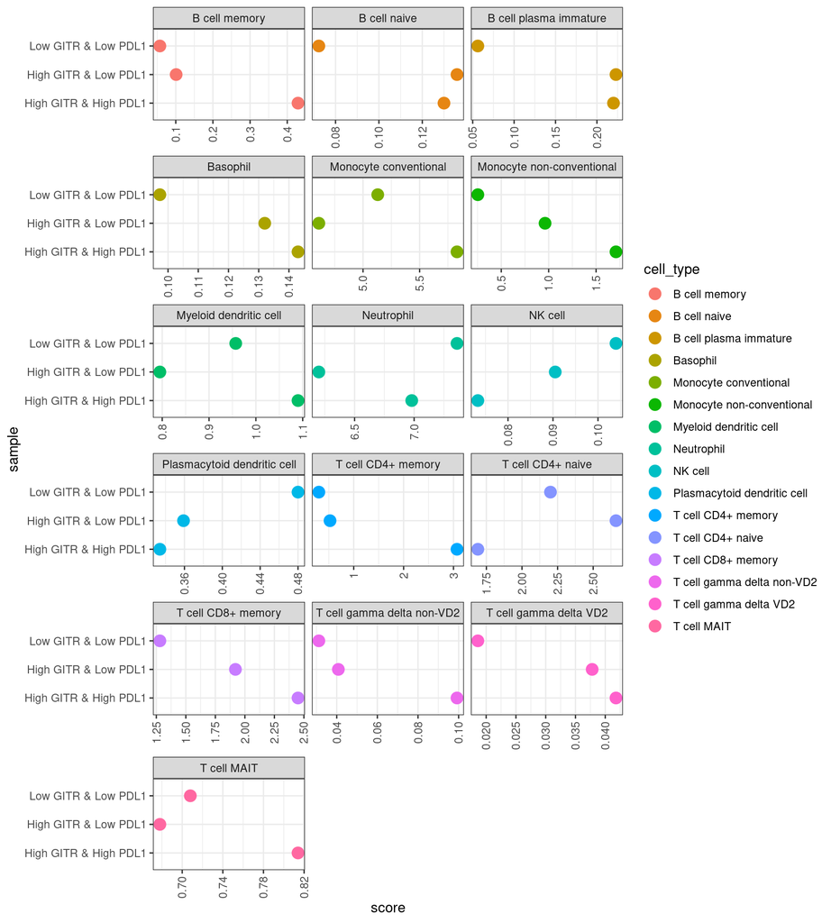

```r
names(group_res_abis) <- c('cell_type', 'High GITR & High PDL1', 'High GITR & Low PDL1', 'Low GITR & Low PDL1', 'group4')
group_res_abis <- group_res_abis %>% dplyr::select(-group4)
group_res_abis <- group_res_abis[rowSums(group_res_abis[,-1]) > 0,]
group_res_abis %>%
    gather(sample, score, -cell_type) %>%
  ggplot(aes(x=sample, y=score, color=cell_type)) +
    geom_point(size=4) +
    facet_wrap(~cell_type, scales='free_x',ncol=3) +
    #scale_color_brewer(palette="Paired", guide=FALSE) +
    coord_flip() +
    theme_bw() +
    theme(axis.text.x = element_text(angle = 90, vjust = 0.5, hjust=1))
```

```r
cat('\n\n\n\n')
```

```r
cat('### ConsensusTME Results')
```

### ConsensusTME Results

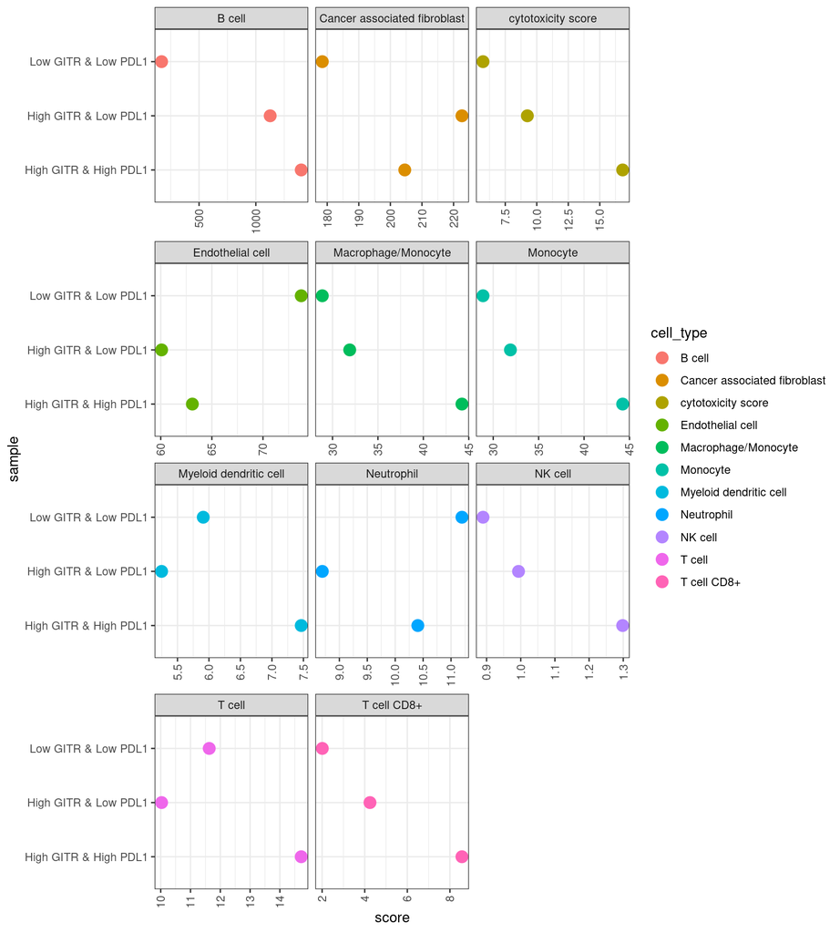

```r
names(group_res_consensus_tme) <- c('cell_type', 'High GITR & High PDL1', 'High GITR & Low PDL1', 'Low GITR & Low PDL1', 'group4')
group_res_consensus_tme <- group_res_consensus_tme %>% dplyr::select(-group4)
group_res_consensus_tme <- group_res_consensus_tme[rowSums(group_res_consensus_tme[,-1]) > 0,]
group_res_consensus_tme %>%
    gather(sample, score, -cell_type) %>%
  ggplot(aes(x=sample, y=score, color=cell_type)) +
    geom_point(size=4) +
    facet_wrap(~cell_type, scales='free_x', ncol=3) +
    #scale_color_brewer(palette="Paired", guide=FALSE) +
    coord_flip() +
    theme_bw() +
    theme(axis.text.x = element_text(angle = 90, vjust = 0.5, hjust=1))
```

```r
#cat('### Quantiseq Results as Table')
#knitr::kable(group_res_quantiseq)


#general trends; tregs and cancer fibroblasts upregulated in condition 2
```

```r
cat('\n\n\n\n')
```

```r
cat('### xCell Results')
```

### xCell Results

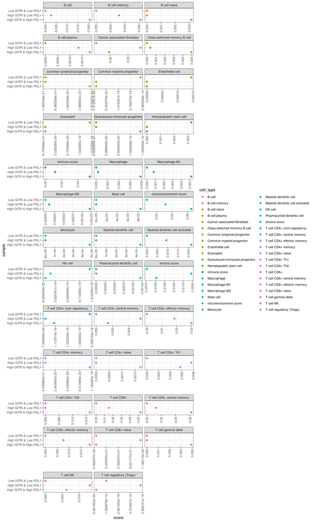

```r
names(group_res_xCell) <- c('cell_type', 'High GITR & High PDL1', 'High GITR & Low PDL1', 'Low GITR & Low PDL1', 'group4')
group_res_xCell <- group_res_xCell %>% dplyr::select(-group4)
group_res_xCell <- group_res_xCell[rowSums(group_res_xCell[,-1]) > 0,]
group_res_xCell %>%
    gather(sample, score, -cell_type) %>%
  ggplot(aes(x=sample, y=score, color=cell_type)) +
    geom_point(size=2) +
    facet_wrap(~cell_type, scales='free_x', ncol=3) +
   # scale_color_brewer(palette="Paired", guide=FALSE) +
    coord_flip() +
    theme_bw() +
    theme(axis.text.x = element_text(angle = 90, vjust = 0.5, hjust=1))
```

```r
cat('\n\n\n')
```

```r
f23 <- top_group2_vs_group3
f23$gene <- rownames(f23)
rownames(f23) <- NULL
f23 <- f23 %>%
    dplyr::filter(abs(logFC) > 1.5, adj.P.Val < 0.05) %>%
    dplyr::select(gene,logFC,adj.P.Val)
names(f23) <- c('gene','LogFC_Group2_vs_Group3','P_Group2_vs_Group3')


f21 <- top_group2_vs_group1
f21$gene <- rownames(f21)
rownames(f21) <- NULL
f21 <- f21 %>%
    dplyr::filter(abs(logFC) > 1.5, adj.P.Val < 0.05) %>%
    dplyr::select(gene,logFC,adj.P.Val)
names(f21) <- c('gene','LogFC_Group2_vs_Group1','P_Group2_vs_Group1')

combined <- bind_rows(f21,f23)
write.table(combined, file='fdr_ipa_tables/gitr_renal_clear_cell.tsv', row.names=FALSE, quote=FALSE, sep='\t')
```

```r
cat('\n\n')
```

```r
cat('# GITR and PDL1 Scatter Plot by Group')
```

# GITR and PDL1 Scatter Plot by Group

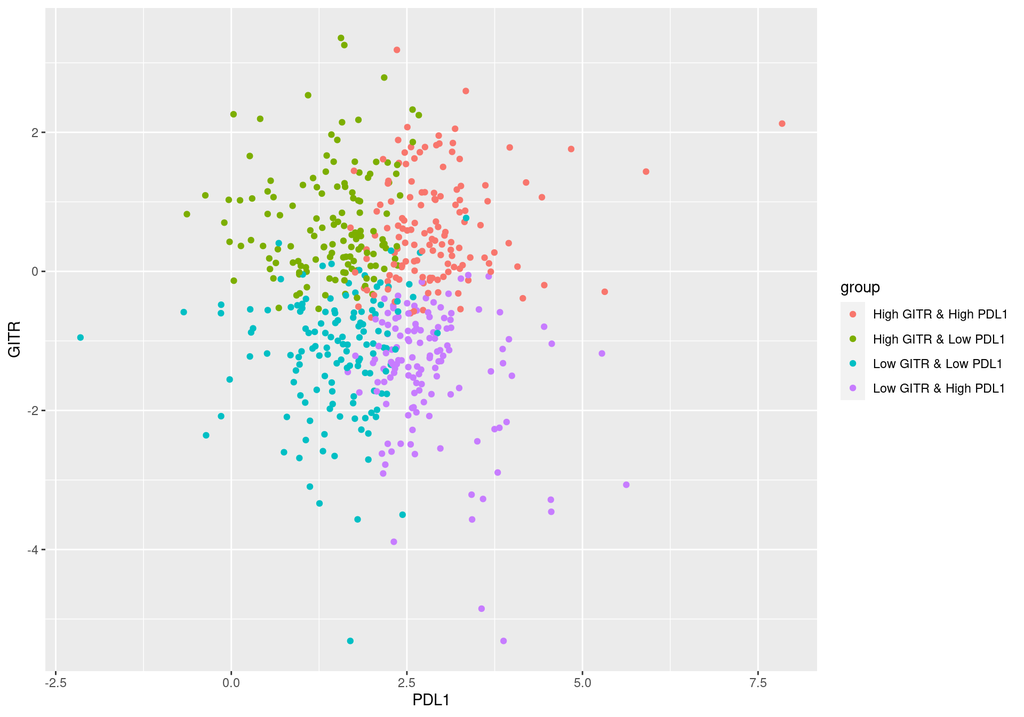

```r
gitr_pdl1_count <- lcpm[c('ENSG00000186891','ENSG00000120217'),]
rownames(gitr_pdl1_count) <- c('GITR','PDL1')
gitr_pdl1_count <- as.data.frame(t(gitr_pdl1_count))
gitr_pdl1_count$sample <- rownames(gitr_pdl1_count)
rownames(gitr_pdl1_count) <- NULL
gitr_pdl1_count <- gitr_pdl1_count %>% dplyr::select(sample,GITR,PDL1)
group_info <- as.data.frame(dge.counts$sample %>% dplyr::select(group)) %>%
    mutate(sample=rownames(dge.counts$sample)) %>%
    select(sample,group)
rownames(group_info) <- NULL

group_gitr_pdl1 <- list(gitr_pdl1_count, group_info) %>% purrr::reduce(full_join, by='sample')

scatter_gitr <- group_gitr_pdl1

scatter_gitr$group <- recode(scatter_gitr$group,
                    '1'='High GITR & High PDL1',
                    '2'='High GITR & Low PDL1',
                    '3'='Low GITR & Low PDL1',
                    '4'='Low GITR & High PDL1'
                    )

ggplot(scatter_gitr, aes(x=PDL1, y=GITR)) +
    geom_point(aes(color=group))
```

# TMB Analysis

## TMB Analysis Using TMB Values Computed by Dr. Bao

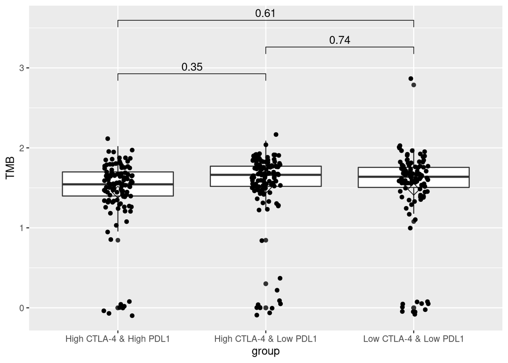

```r
library(rstatix)
library(ggpubr)


box <- og_tmb_matched_groups %>% dplyr::filter(group != 4)
#box <- box %>% dplyr::filter(TMB < 5000)
box$TMB <- log10(box$TMB)
box$group <- recode(box$group,
                    '1'='High CTLA-4 & High PDL1',
                    '2'='High CTLA-4 & Low PDL1',
                    '3'='Low CTLA-4 & Low PDL1',
                    '4'='Low CTLA-4 & High PDL1'
                    )
comp <- list(c('High CTLA-4 & High PDL1','High CTLA-4 & Low PDL1'),
             c('High CTLA-4 & Low PDL1','Low CTLA-4 & Low PDL1'),
             c('High CTLA-4 & High PDL1','Low CTLA-4 & Low PDL1')
             )

b <- ggplot(box, aes(x=group, y=TMB)) +
    geom_boxplot() +
    stat_summary(fun.y=mean, geom='point', shape=23, size=4) +
    stat_compare_means(comparisons=comp, label='p.format', method='t.test') +
    geom_jitter(position=position_jitter(w=0.1, h=0.1))

#pdf('box')
b
```

```r
#dev.off()
cat('\n\n\n')
```

```r
#https://www.datanovia.com/en/blog/how-to-add-p-values-onto-basic-ggplots/
```